# TP2 de Modèles à Structure Latente

Rajeeth Arumainathan, Jules Aubry, Youssef Ben Fadhel

2023-12-20

# Modèles de mélange

1. On note ici les paramètres du mélange par $\theta=(\mathbf{\pi}, \mathbf{\mu}, \mathbf{\sigma^2})$.  
   On a choisi:
- Dans le cas de la densité bimodale : $\pi=(1/3,1/3,1/3), \, \mu=(-3,0,1) \, ,\sigma^2=(1,1,1)$.
- Dans le cas de la densité unimodale symétrique : $\pi=(1/3,1/3,1/3), \, \mu=(-1,0,1) \, ,\sigma^2=(1,1,1)$.
- Dans le cas de la densité unimodale asymétrique : $\pi=(2/3,1/6,1/6), \, \mu=(-1,0,1) \, ,\sigma^2=(1,1,1)$.
- Dans le cas de la densité trimodale : $\pi=(1/3,1/3,1/3), \, \mu=(-4,0,4) \, ,\sigma^2=(1,1,1)$.

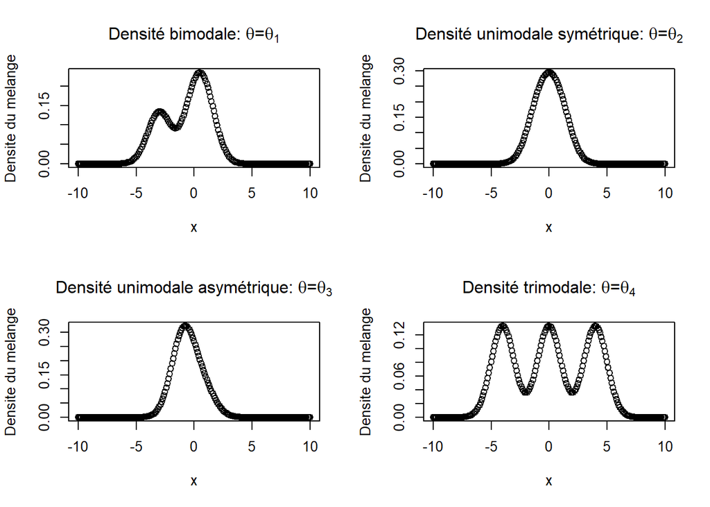

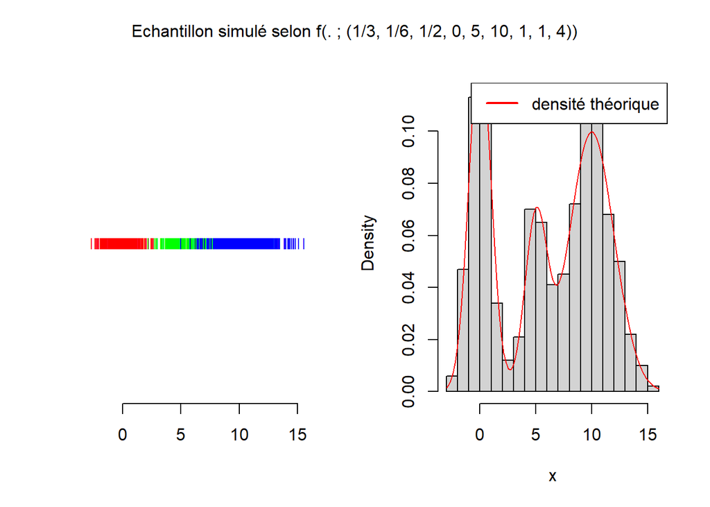

On trace les mêmes graphiques pour les modèles de mélange de la question 1.

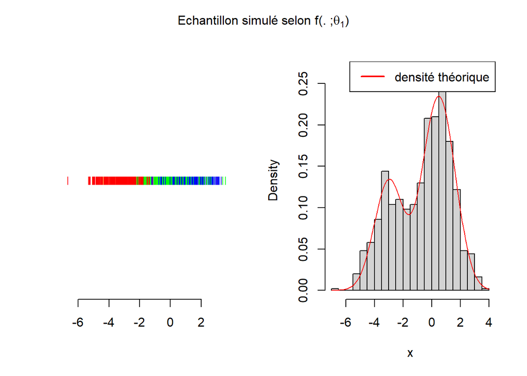

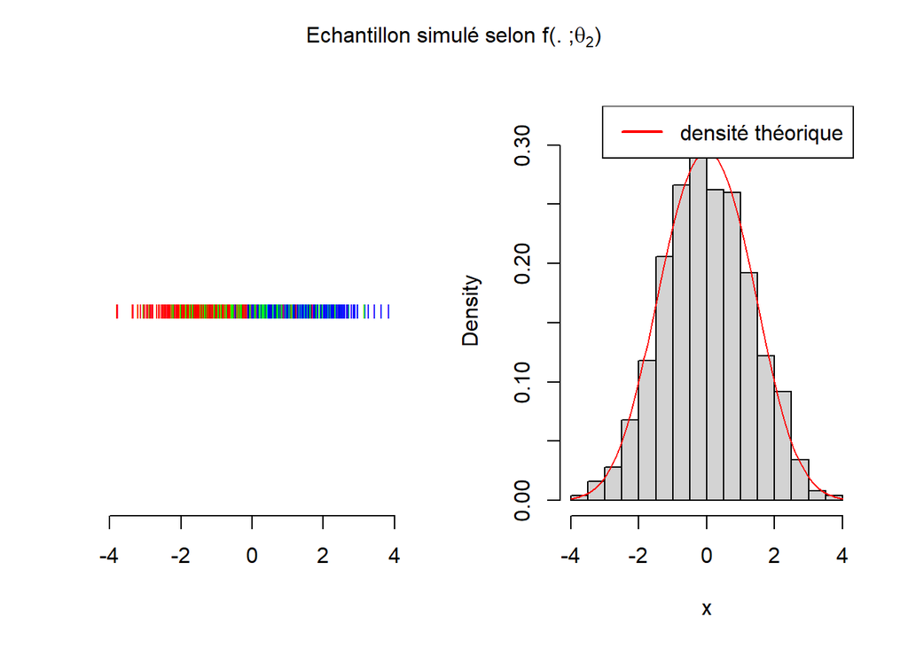

On affiche les premières valeurs des vraies classes puis celles calculées par la règle du MAP:

```r
classes_map[1:20]
```

```
##  [1] 2 3 1 3 3 3 2 3 3 1 2 1 3 3 1 1 3 1 3 3
```

```r
sample_gmm[,2][1:20]
```

```
##  [1] 2 3 1 3 3 3 2 3 3 1 2 1 3 3 1 1 3 1 3 3
```

On affiche aussi les matrices de confusion pour les 3 simulations de la question 2:

```r
confusion(classes_map, sample_gmm[,2], 3)
```

```
##      [,1] [,2] [,3]
## [1,]  320    1    0
## [2,]    1  175   36
## [3,]    0    2  465
```

On peut voir que l’instance de mauvaise classification qui est la plus significative est lorsque la MAP prédit la classe $2$ alors que l’observation appartient à la classe $3$. En effet, même si les moyennes des densités conditionnelles à $Z$ sont bien séparées ($0$, $5$ et $10$), le fait que la troisième classe ait une proportion beaucoup plus importante dans le mélange que la deuxième ($1/2$ contre $1/6$) ainsi qu’une variance associée plus importante que la deuxième ($4$ contre $1$) explique ce taux d’erreur du MAP.  
La matrice de confusion du mélange avec paramètre $π=(1/3,1/3,1/3),μ=(−3,0,1),σ^2=(1,1,1)$ est:

```r
confusion(classes_map_1, sample_gmm_1[,2], 3)
```

```
##      [,1] [,2] [,3]
## [1,]  308   26    1
## [2,]   23  197  106
## [3,]    0  113  226
```

```r
confusion(classes_map_2, sample_gmm_2[,2], 3)
```

```
##      [,1] [,2] [,3]
## [1,]  247   87   19
## [2,]   77  129   85
## [3,]   22  113  221
```

La densité conditionnelle de la classe $2$ déborde sur celles des classes $1$ et $3$, le MAP à du mal à distinguer la classe $1$ de la classe $2$ ainsi que la classe $3$ de la classe $2$.

On choisit de représenter la log-vraisemblance pour les paramètres inconnus $(\mu_1, \mu_2)$, avec tous les autres paramètres fixés à leur vraie valeur. On constate deux maxima locaux sur le graphique de la log-vraisemblance, aux coordonnées approximative ($0$,$5$) et ($5$, $0$)

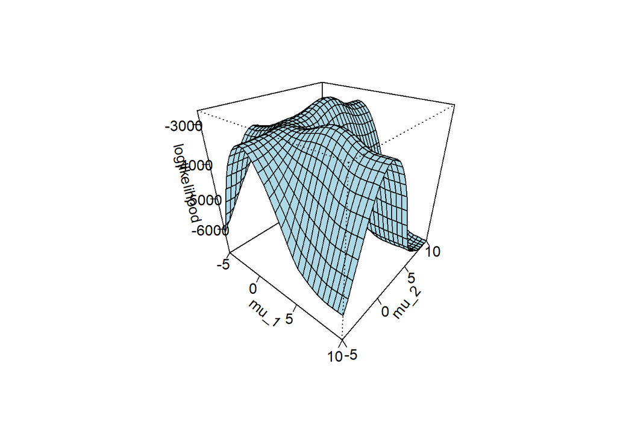

Le maximum de $l(\mu_1, \mu_2)$ est bien atteint en $(0,5)$ comme espéré:

```r
c(range_mu[row(z)[which.max(z)]], range_mu[col(z)[which.max(z)]])
```

```
## [1] 0 5
```

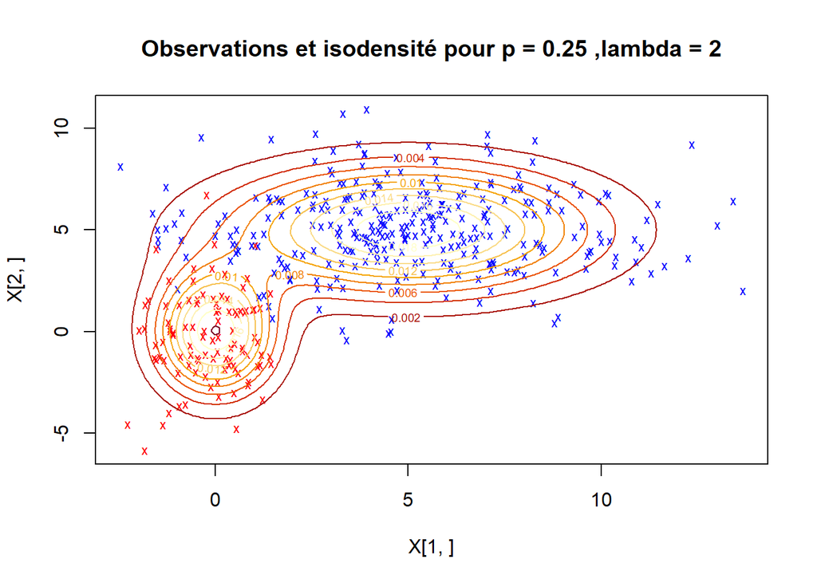

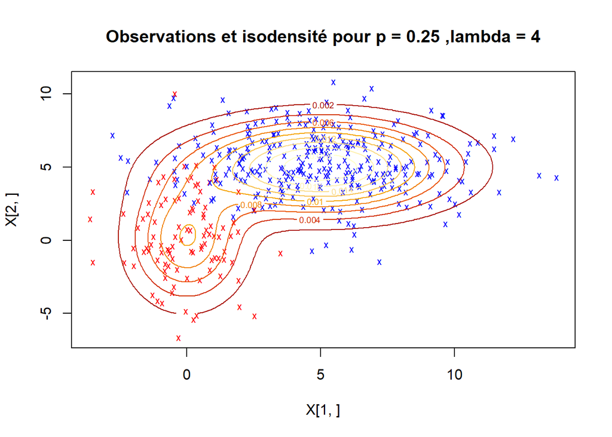

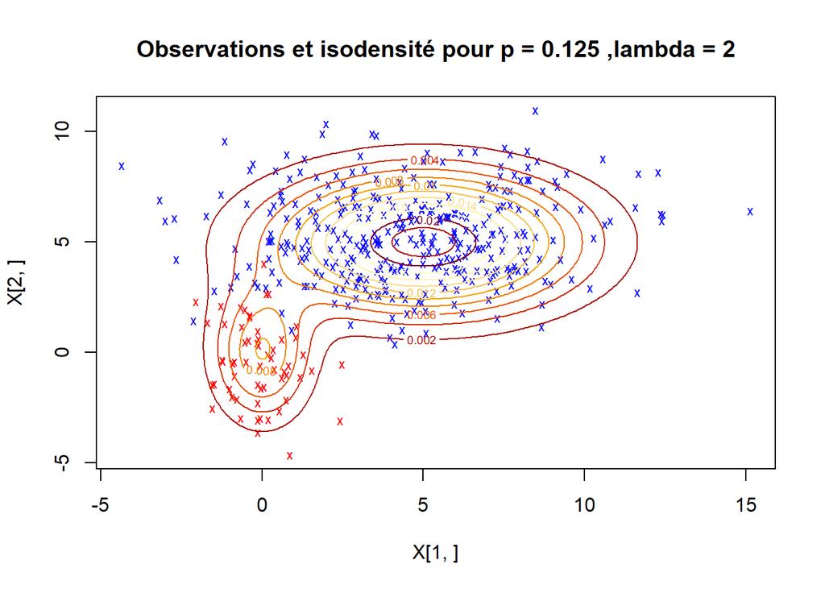

# Algorithme EM, dimension 1

1. 1. Ici, $\Theta = \left\{ (\pi_1, \ldots ,\pi_J, \mu_1, \ldots ,\mu_J, {\sigma_1}^2, \ldots ,{\sigma_J}^2) \in \Delta_J \times \mathbb{R}^J \times \mathbb{R}_{>0}^j \right\}$ où $\Delta_J$ est le $J$-simplexe. Dans le cadre de notre échantillon $\left\{ X_{1}, \ldots, X_{n} \right\}$ supposé issu d’une modèle GMM à J classes avec variable latente $Z$, l’algorithme EM s’écrit:

*Initialisation*: choix de $\theta^{(0)}$

*Récursion:* pour $t=1, \ldots , t_{max}$

*(E):* On cherche à calculer $Q(\theta, \theta^{(t)}) = \mathbb{E}[{\log L_c(\theta | X_{1}, \ldots ,X_{n})}]$. La log-vraisemblance complète est $\log \mathcal{L_c}(\theta) = \sum_{j=1}^J \sum_{i=1}^n Z_{i,j} \log(\pi_j \phi(X_{i},\mu_j,\sigma_j^2)$. Donc $Q(\theta, \theta^{(t)}) = \sum_{j=1}^J \sum_{i=1}^n \tau_{ij}(\theta^{(t)}) (\log(\pi_j + \phi(X_{i},\mu_j,\sigma_j^2)$ Alors: $\begin{equation*} Q(\theta, \theta^{(t)})=\sum_{j=1}^J \log(\pi_j) \sum_{i=1}^n \tau_{ij} + \sum_{j=1}^J \sum_{i=1}^n \tau_{ij} \log(\phi(X_{i},\mu_j,\sigma_j^2)) \quad (1)\end{equation*}$.  
On définit $\rho_j=\sum_{i=1}^n\tau_{ij}(\theta^{(t)})=\mathbb{E}[\#\{Z_{i,j}=1\}]$.

*(M):* On cherche $\theta^{(t+1)} = \arg\max_{\theta \in \Theta} Q(\theta, \theta^{(t)})$. Les problèmes d’optimisations en $\pi$ et en ($\mu, \sigma^2$) sont indépendants par la décomposition (1) de la fonction objectif. On maximise d’abord $\sum_{j=1}^J \rho_j \log(\pi_j)$ sous les contraintes $\forall j, \pi_j \geq 0$ et $\sum_{k=1}^J \pi_k = 1$. Le Lagrangien est donné par $\mathcal{L}(\pi, \lambda, \mu) = \sum_{j=1}^J \rho_j \log(\pi_j) + \lambda(\sum_{j=1}^J \pi_j - 1) - \sum_{j=1}^J \mu_j\pi_j$.

$\forall j=1, \ldots, J$, on a :

$$\begin{equation*}
\left\{
\begin{array}{ll}
\partial_{\pi_j} \mathcal{L}(\pi^{*}, \lambda^{*}, \mu^{*}) & = 0 =
\frac{\rho_j}{\pi_j^{*}} + \lambda^{*} \quad (2) \\
\partial_{\lambda} \mathcal{L}(\pi^{*}, \lambda^{*}, \mu^{*}) & = 0
\quad (3) \\
\partial_{\mu_j} \mathcal{L}(\pi^{*}, \lambda^{*}, \mu^{*}) & = 0
\end{array}
\right.
\end{equation*}$$

De (2) et (3), on tire $\lambda^* = - \sum_{k=1}^J \rho_k$ et $\pi_j^* = \frac{\rho_j}{\sum_{k=1}^J \rho_k}$.

Or, $\sum_{k=1}^J \rho_k = \sum_{i=1}^n \sum_{j=1}^J \mathbb{E}[Z_{ij} | X_1, \ldots, X_n] = n$, d’où $\pi_j^*= \frac{\rho_j}{n}$

Maintenant, on maximise $\sum_{i=1}^n \sum_{j=1}^J \tau_{ij} \phi(X_{i},\mu_j,\sigma_j^2)$ sur $\mathbb{R}^J \times \mathbb{R}_{>0}^J$.

Cela revient à maximiser $\forall j=1, \ldots, J$, la fonction $g(\mu_j, \sigma_j^2) = \sum_{i=1}^n \tau_{ij}\phi(X_{i};\mu_j,\sigma_j^2)$ qui est $C^2$ convexe sur l’ouvert $\mathbb{R}^J \times \mathbb{R}_{>0}^J$.
On cherche donc $(\hat{\mu}_k, \hat{\sigma_k}^{2})$ qui annule $\nabla {g}$. Cela donne:
$$\partial_{\sigma_j^2} g (\hat{\mu}_j,
\hat{\sigma_j}^{2}) = 0 \quad \Leftrightarrow \quad
\frac{-1}{\hat{\sigma_j}^{2}} \sum_{i=1}^n \tau_{ij} (\hat{\mu_j} - X_i)
= 0 \quad \Leftrightarrow \quad \hat{\mu_j} = \frac{1}{\rho_j}
\sum_{i=1}^n \tau_{ij} X_{i}$$
Aussi, pour la variance :
$$\partial_{\sigma_j^2} g (\hat{\mu}_j,
\hat{\sigma_j}^{2}) = 0 \quad \Leftrightarrow \quad -\frac{1}{2}
\sum_{i=1}^n \frac{\rho_{ij}}{\hat{\sigma_j}^2}+
\frac{1}{2\hat{\sigma}_j^{2}} \sum_{i=1}^n \tau_{ij}(X_i -
\hat{\mu_j})^2 = 0\quad \Leftrightarrow \quad \hat{\sigma}_j^2 =
\frac{1}{\rho_j} \sum_{i=1}^n \tau_{ij} (X_i - \hat{\mu_j})^2$$
2. a)

On présente la sortie de l’algorithme EM pour l’échantillon de la question 2. de l’exercice précédent avec les paramètre initiaux:

- $\pi_0=(1/J,\ldots,1/J)$
- les composantes de $\mu_{0}$ choisies uniformément parmi les observations
- $\sigma_0^2=\hat{\mathbb{V}}\{X_1,\ldots,X_n\}$ la variance empirique de l’échantillon.

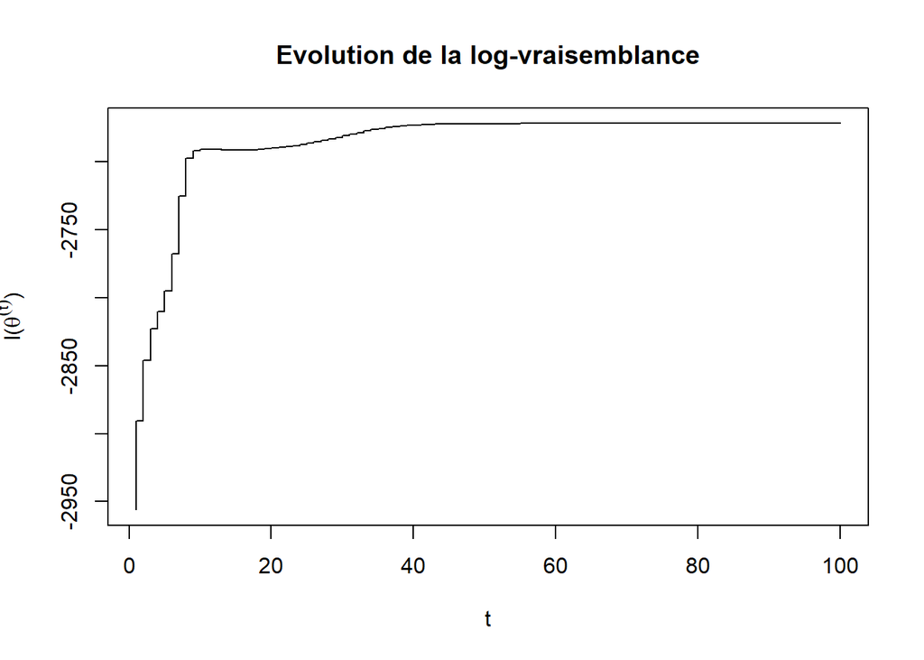

On retrouve bien le résultat du cours qui assure que la vraisemblance croît à chaque pas de temps. On remarque aussi un palier autour de la $10^e$ itération. Si on notre critère d’arrêt nous faisait nous arrêter quand $l$ n’évolue plus assez, on aurait perdu un petit gain en vraisemblance en nous arrêtant trop tôt.  
c),d) Les paramètres de sortie de l’EM, la log-vraisemblance à l’itération finale sont présentés, ainsi que la densité ajustée puis la classification (comparée à celle du MAP).

```r
EM_output$theta
```

```
## $pi
## [1] 0.4983773 0.1814359 0.3201869
##
## $mu
## [1] 10.11727100  5.01863925 -0.03796466
##
## $var
## [1] 3.6121699 0.9406381 0.9418274
```

```r
EM_output$ll[tmax]
```

```
## [1] -2671.698
```

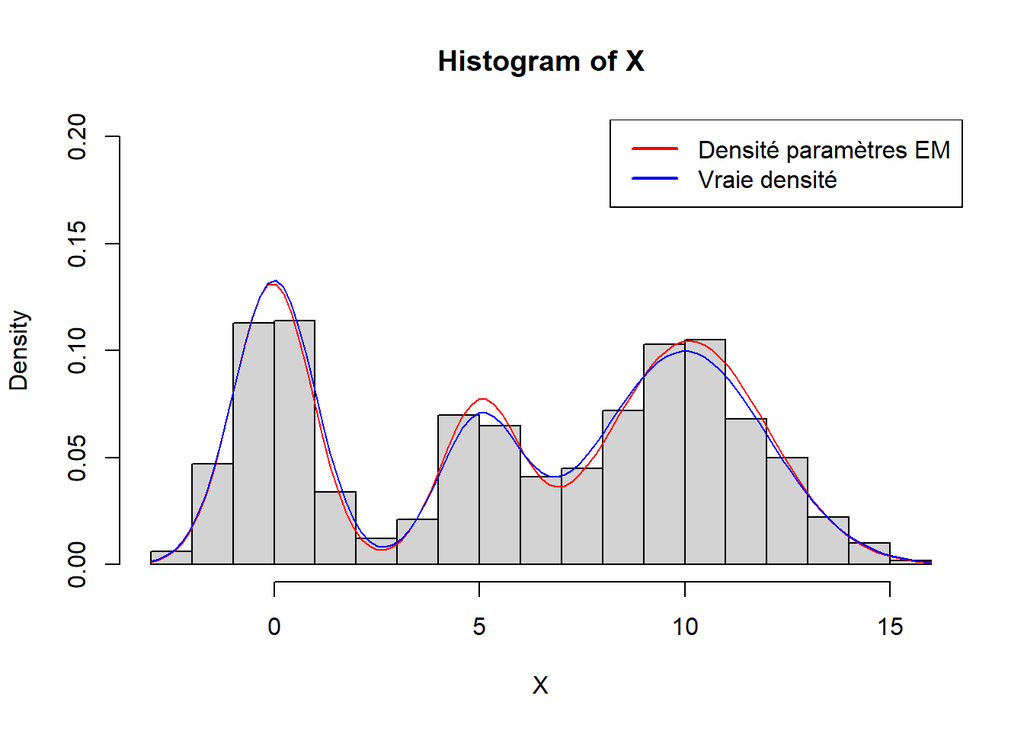

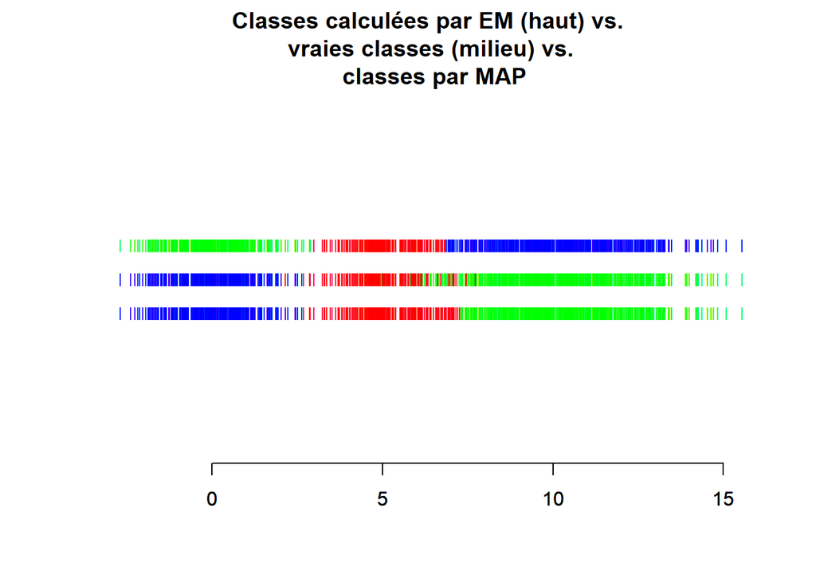

```
## $Confusion_EM
##      [,1] [,2] [,3]
## [1,]    0    9  475
## [2,]    0  165   26
## [3,]  321    4    0
##
## $confusion_map
##      [,1] [,2] [,3]
## [1,]  320    1    0
## [2,]    1  175   36
## [3,]    0    2  465
```

```r
EM_results(X, theta_EM, theta_true, true_classes, classes_map)
```

Remarque: l’algorithme a interverti le label des classes $1$ et $3$. b) On essaie d’abord de choisir le moyennes initiales en les éloignant le plus possible, i.e $\mu_j=X_{(j)}$:

```r
EM_output$theta
```

```
## $pi
## [1] 0.3201858 0.1814470 0.4983683
##
## $mu
## [1] -0.037973  5.018705 10.117338
##
## $var
## [1] 0.9418089 0.9407805 3.6119685
```

```r
EM_output$ll[tmax]
```

```
## [1] -2671.697
```

Puis on choisit comme valeurs initiales les vraies valeurs du paramètre :

```r
EM_output$theta
```

```
## $pi
## [1] 0.3201869 0.1814358 0.4983773
##
## $mu
## [1] -0.03796463  5.01863892 10.11727059
##
## $var
## [1] 0.9418275 0.9406374 3.6121711
```

```r
EM_output$ll[tmax]
```

```
## [1] -2671.698
```

On constate que dans ce cas de figure particulier, ces quelques valeurs de paramètre initial ne changent pas vraiment la donne, tant au niveau des paramètres de sortie que de la classification finale (si on prend on compte le label switching).

# Algorithme EM, dimension quelconque (Mixmod)

2. On commence par simuler un mélange gaussien à partir de trois lois normales de moyennes $(-1, 0, 2)$, de variances $(1, 1, 1)$ et avec des proportions $(0.4, 0.3, 0.3)$.

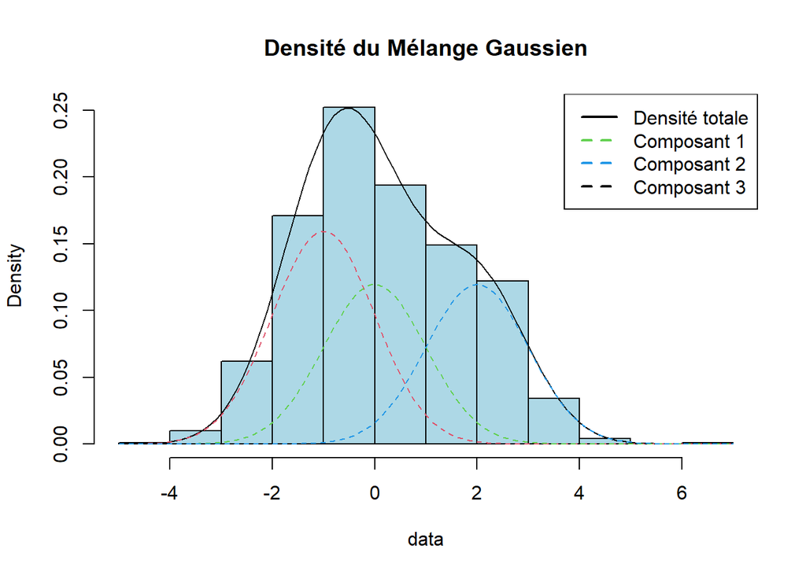

À présent, on peut estimer la densité du modèle de mélange avec la fonction MixmodCluster du package Rmixmod. Cette fonction calcule un modèle de mélange optimal en fonction des critères fournis, et de la liste des modèles définis, à l’aide de l’algorithme spécifié.

3. À présent, jouons un peu avec les arguments d’entrée de Rmixmod, nbCluster et models :

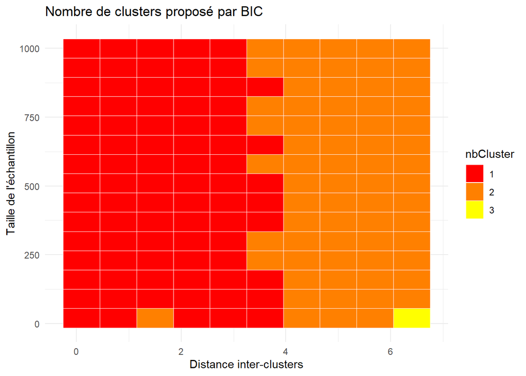

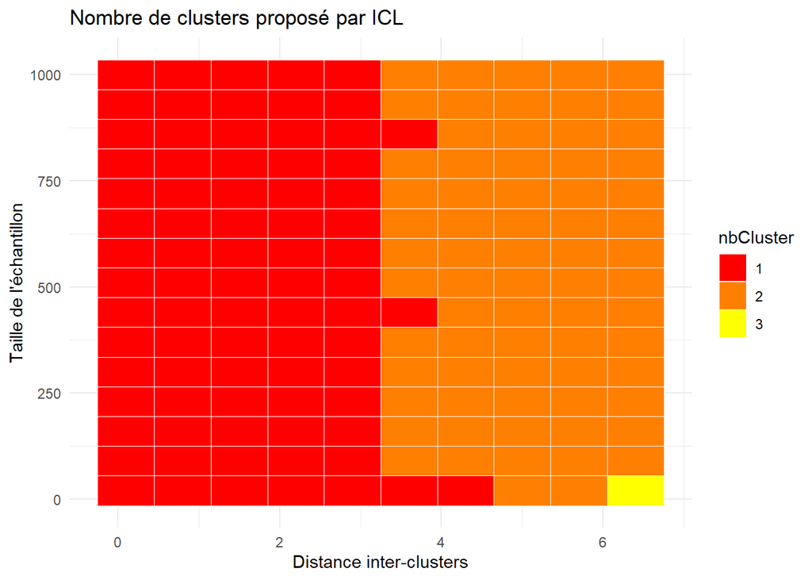

Le clustering par BIC et celui par ICL on sur cet example des performances similaires en termes de détection du nombre de cluster, ils sélectionnent le vrai nombre de composantes lorsque les centres des classes sont éloignés (on aurait pu s’attendre à ce que la taille de l’échantillon ait une importance, mais ce n’est pas le cas ici).

2. On charge le fichier “seeds_dataset.txt” présent dans le répertoire courant

On a choisi de chercher le nombre de classes entre $1$ et $8$, voici les résultats du clustering par critère du BIC puis par celui du ICL:

```r
seeds_BIC["bestResult"]["nbCluster"]
```

```
## [1] 7
```

```r
seeds_BIC["bestResult"]["model"]
```

```
## [1] "Gaussian_pk_Lk_C"
```

```r
seeds_ICL["bestResult"]["nbCluster"]
```

[output not shown]

```r
seeds_ICL["bestResult"]["model"]
```

```
## [1] "Gaussian_pk_Lk_C"
```

```
## [1] 5
```

```
## [1] 6
```

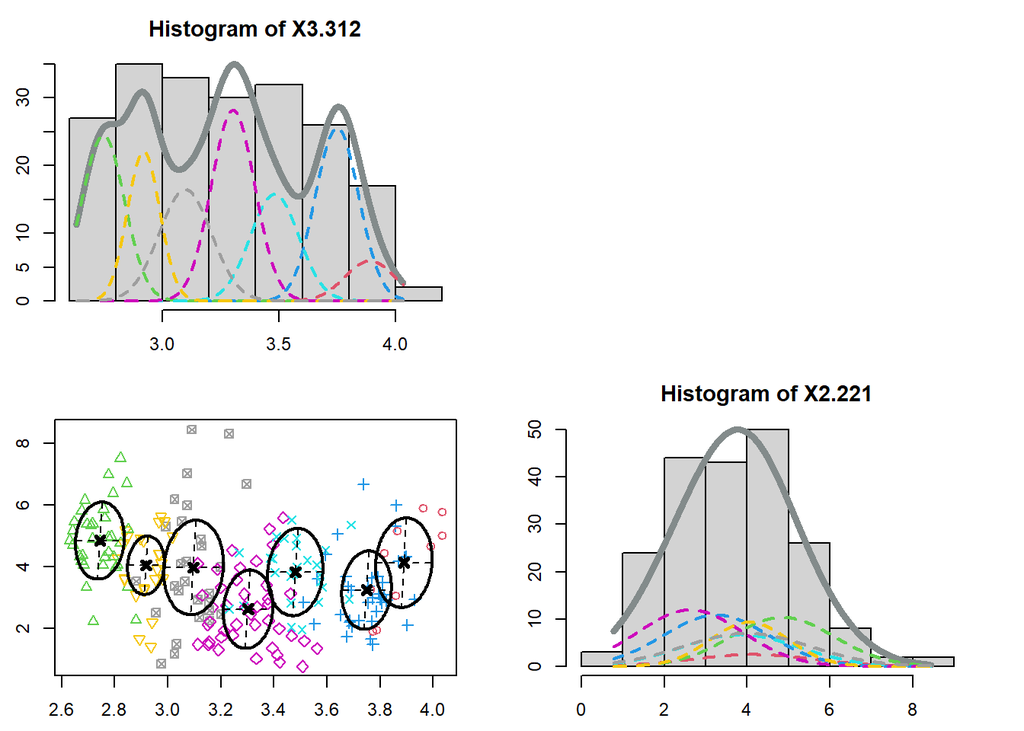

```
## [1] 5
```

```
## [1] 6
```

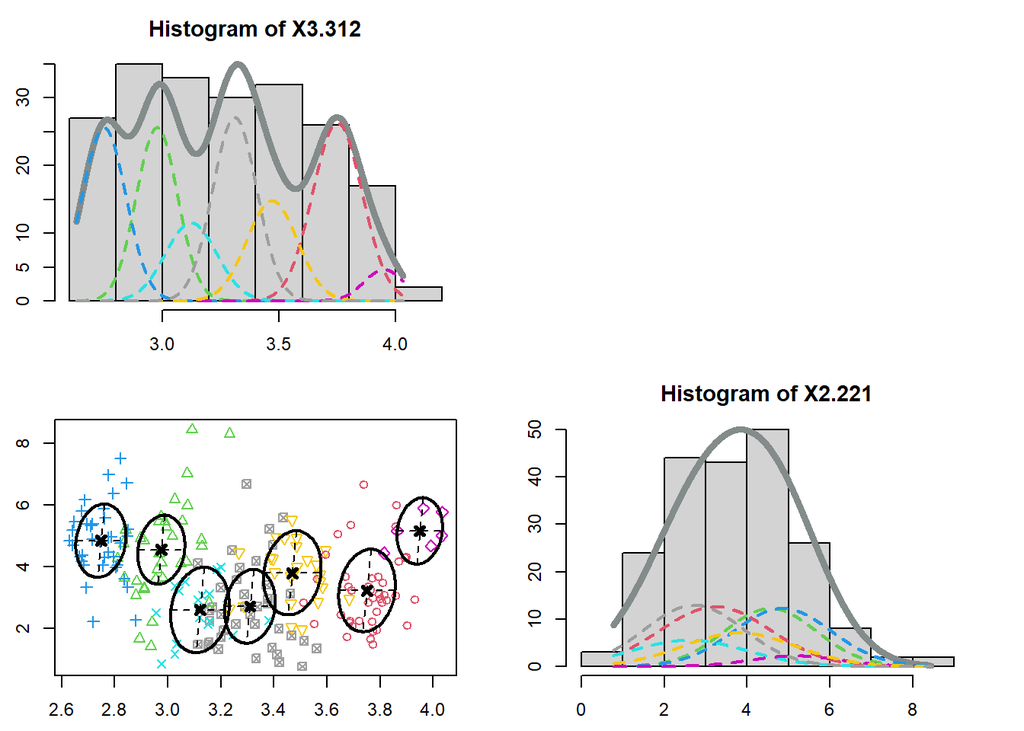

- pour le modèle [pk_L_I]:

On représente les histogrammes des marginales de l’échantillon.

```r
seeds_BIC["bestResult"]["nbCluster"]
```

```
## [1] 8
```

```r
seeds_ICL["bestResult"]["nbCluster"]
```

```
## [1] 8
```

```
## [1] 1 2 3 4 5 6 7
```

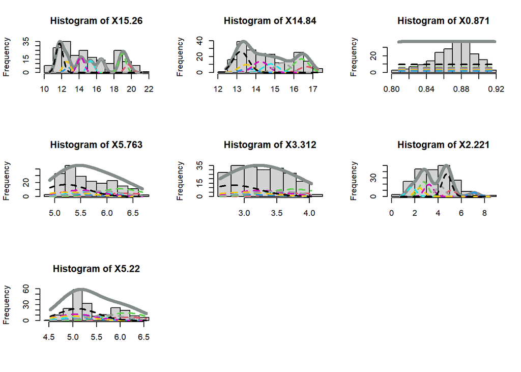

```r
hist(seeds_BIC)
```

```
## [1] 1 2 3 4 5 6 7
```

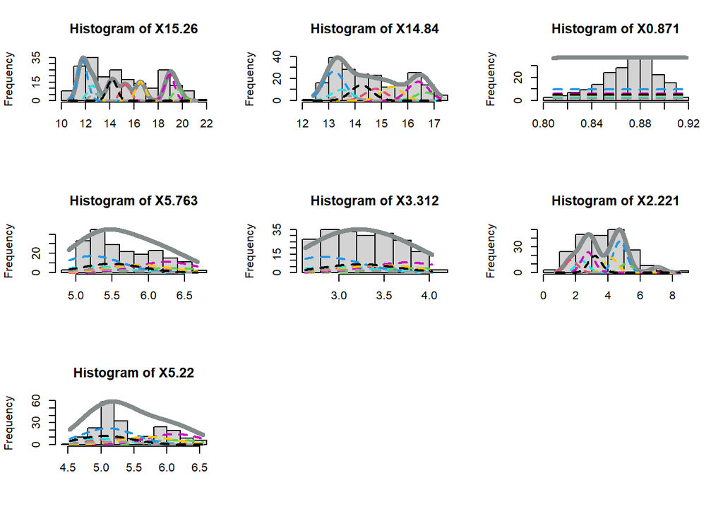

```r
hist(seeds_ICL)
```

- pour le modèle [pk_Lk_C]:

```r
seeds_BIC["bestResult"]["nbCluster"]
```

```
## [1] 7
```

```r
seeds_ICL["bestResult"]["nbCluster"]
```

```
## [1] 6
```

```
## [1] 1 2 3 4 5 6 7
```

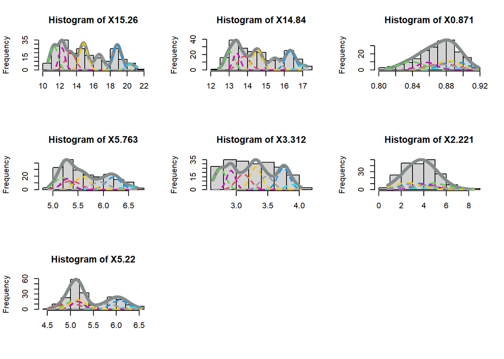

```r
hist(seeds_BIC)
```

```
## [1] 1 2 3 4 5 6 7
```

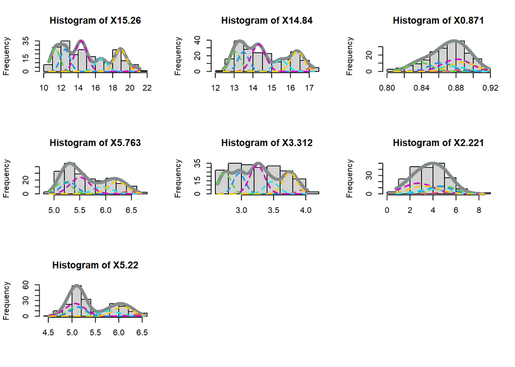

```r
hist(seeds_ICL)
```

Le fait d’avoir permis une plus grande généralité à la matrice de covariance a permis d’améliorer considérablement le clustering. Toutes les composantes sont pertinentes au vu des histogrammes.